# Daniel Guthrie

## 1 (a)

```r
options(warn = -1)
```

```r
library(pls)
library(randomForest)
library(tidyverse)
set.seed(4700)
```

```r
# Reading txt file and converting to data frame

BodyDF=data.frame(read.table("body.dat.txt",header=F))
colnames(BodyDF) = c("BiacromialDiam", "BiiliacDiam", "BitrochantericDiam", "ChestDepth", "ChestDiam", "ElbowDiam", "WristDiam", "KneeDiam", "AnkleDiam",
"ShoulderGirth", "ChestGirth", "WaistGirth", "NavelGirth", "HipGirth", "ThighGirth", "BicepGirth", "ForearmGirth", "KneeGirth",
"CalfMaxGirth", "AnkleMinGirth", "WristMinGirth",
"Age", "Weight", "Height", "Gender")

#Defining predictor variable X and response variable Y:

Y=cbind(BodyDF$Age, BodyDF$Weight, BodyDF$Height, BodyDF$Gender)


X=cbind(BodyDF$BiacromialDiam,BodyDF$BiiliacDiam,BodyDF$BitrochantericDiam,BodyDF$ChestDepth,BodyDF$ChestDiam,BodyDF$ElbowDiam,BodyDF$WristDiam,BodyDF$KneeDiam,BodyDF$AnkleDiam,BodyDF$ShoulderGirth,BodyDF$ChestGirth,BodyDF$WaistGirth,BodyDF$NavelGirth,BodyDF$HipGirth,BodyDF$ThighGirth,BodyDF$BicepGirth,BodyDF$ForearmGirth,BodyDF$KneeGirth,BodyDF$CalfMaxGirth,BodyDF$AnkleMinGirth,BodyDF$WristMinGirth)
```

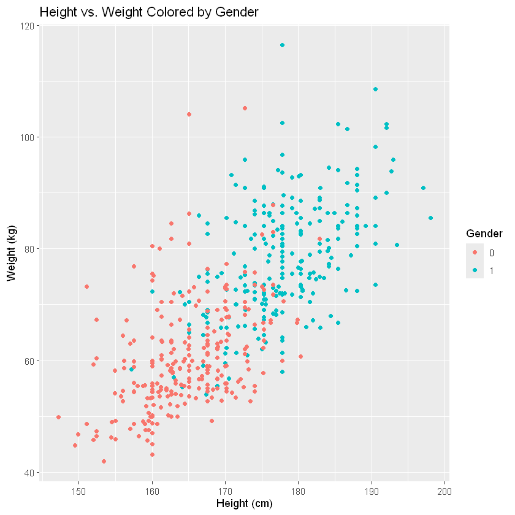

```r
# Defining predictors and response
X <- BodyDF[, 1:21]
Y <- BodyDF[, c("Age", "Weight", "Height", "Gender")]

# Visualizing Height vs Weight by Gender
library(ggplot2)
ggplot(BodyDF, aes(x = Height, y = Weight, color = as.factor(Gender))) +
  geom_point() +
  labs(title = "Height vs. Weight Colored by Gender",
       x = "Height (cm)", y = "Weight (kg)", color = "Gender")
```

## (b)

```r
set.seed(1)
n <- nrow(X)
test_idx <- sample(1:n, 200)
train_idx <- setdiff(1:n, test_idx)

X_train <- X[train_idx, ]
X_test <- X[test_idx, ]
Y_train <- Y[train_idx, ]
Y_test <- Y[test_idx, ]

library(pls)
pcr_fit <- pcr(Weight ~ ., data = data.frame(Weight = Y_train$Weight, X_train),
               scale = TRUE, validation = "CV")

plsr_fit <- plsr(Weight ~ ., data = data.frame(Weight = Y_train$Weight, X_train),
                 scale = TRUE, validation = "CV")
```

### Scaling is important because the predictors are using different scales of measurements.

## (c)

```r
summary(pcr_fit)
summary(plsr_fit)
```

```
Data: 	X dimension: 307 21
	Y dimension: 307 1
Fit method: svdpc
Number of components considered: 21

VALIDATION: RMSEP
Cross-validated using 10 random segments.
       (Intercept)  1 comps  2 comps  3 comps  4 comps  5 comps  6 comps
CV           13.54    3.267    3.094    2.882    2.798    2.788    2.792
adjCV        13.54    3.266    3.093    2.849    2.795    2.785    2.789
       7 comps  8 comps  9 comps  10 comps  11 comps  12 comps  13 comps
CV       2.767    2.764    2.779     2.789     2.787     2.784     2.793
adjCV    2.751    2.759    2.774     2.784     2.782     2.778     2.786
       14 comps  15 comps  16 comps  17 comps  18 comps  19 comps  20 comps
CV        2.783     2.802     2.775     2.718     2.725     2.729     2.747
adjCV     2.775     2.794     2.773     2.707     2.715     2.719     2.736
       21 comps
CV        2.763
adjCV     2.751

TRAINING: % variance explained
        1 comps  2 comps  3 comps  4 comps  5 comps  6 comps  7 comps  8 comps
X         65.57    76.91    81.32    85.50    87.71    89.48    90.84    92.18
Weight    94.19    94.82    95.76    95.82    95.89    95.92    96.03    96.04
        9 comps  10 comps  11 comps  12 comps  13 comps  14 comps  15 comps
X         93.40     94.52     95.45     96.29     97.07     97.73     98.29
Weight    96.05     96.05     96.05     96.07     96.13     96.18     96.19
        16 comps  17 comps  18 comps  19 comps  20 comps  21 comps
X          98.68     99.05     99.38     99.63     99.84    100.00
Weight     96.21     96.37     96.46     96.46     96.46     96.46
Data: 	X dimension: 307 21
	Y dimension: 307 1
Fit method: kernelpls
Number of components considered: 21

VALIDATION: RMSEP
Cross-validated using 10 random segments.
       (Intercept)  1 comps  2 comps  3 comps  4 comps  5 comps  6 comps
CV           13.54    3.176    2.851    2.749    2.733    2.751     2.74
adjCV        13.54    3.175    2.849    2.745    2.725    2.739     2.73
       7 comps  8 comps  9 comps  10 comps  11 comps  12 comps  13 comps
CV       2.738    2.736    2.740     2.743     2.745     2.746     2.746
adjCV    2.728    2.726    2.729     2.733     2.734     2.735     2.735
       14 comps  15 comps  16 comps  17 comps  18 comps  19 comps  20 comps
CV        2.746     2.746     2.746     2.746     2.746     2.746     2.746
adjCV     2.735     2.735     2.735     2.735     2.735     2.735     2.735
       21 comps
CV        2.746
adjCV     2.735

TRAINING: % variance explained
        1 comps  2 comps  3 comps  4 comps  5 comps  6 comps  7 comps  8 comps
X         65.56    75.21    81.07    82.65    84.21    87.06    89.29    90.35
Weight    94.54    95.72    96.12    96.34    96.43    96.45    96.46    96.46
        9 comps  10 comps  11 comps  12 comps  13 comps  14 comps  15 comps
X         91.82     92.56     93.28     94.06     94.61     95.37     96.40
Weight    96.46     96.46     96.46     96.46     96.46     96.46     96.46
        16 comps  17 comps  18 comps  19 comps  20 comps  21 comps
X          97.14     97.69     98.29     98.68     99.72    100.00
Weight     96.46     96.46     96.46     96.46     96.46     96.46
```

### PLSR explains more of the weight variance in fewer componenets. PCR captures more predictor variance eariler on. Both eventually explain 96.46% of the weight variance.

## (d)

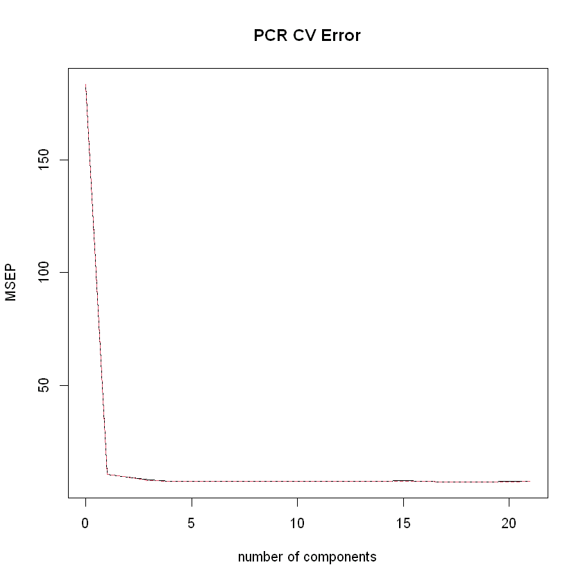

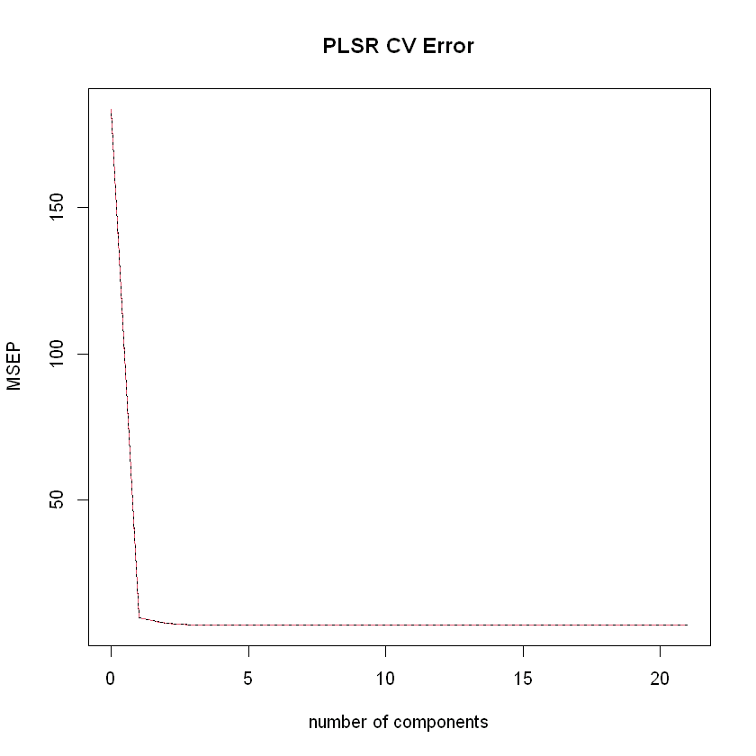

```r
validationplot(pcr_fit, val.type = "MSEP", main = "PCR CV Error")
validationplot(plsr_fit, val.type = "MSEP", main = "PLSR CV Error")
```

```r
ncomp_pcr <- which.min(pcr_fit$validation$PRESS)
ncomp_plsr <- which.min(plsr_fit$validation$PRESS)
ncomp_pcr
ncomp_plsr
```

17

4

### Choosing 17 components for pcr and 4 for plsr because they minimize the sum of squared differences between predicted and actual values.

## (e)

```r
lm_fit <- lm(Weight ~ ., data = data.frame(Weight = Y_train$Weight, X_train))
step_fit <- step(lm_fit, direction = "backward", trace = 0)
summary(step_fit)
```

```
Call:
lm(formula = Weight ~ BiacromialDiam + BiiliacDiam + ChestDepth +
    ChestDiam + ElbowDiam + AnkleDiam + ShoulderGirth + ChestGirth +
    WaistGirth + HipGirth + ThighGirth + ForearmGirth + KneeGirth +
    CalfMaxGirth, data = data.frame(Weight = Y_train$Weight,
    X_train))

Residuals:
    Min      1Q  Median      3Q     Max
-7.0178 -1.7655 -0.0442  1.6504  6.5777

Coefficients:
                Estimate Std. Error t value Pr(>|t|)
(Intercept)    -97.01280    3.31620 -29.254  < 2e-16 ***
BiacromialDiam   0.23241    0.09772   2.378 0.018041 *
BiiliacDiam      0.37196    0.09182   4.051 6.54e-05 ***
ChestDepth       0.41997    0.11073   3.793 0.000181 ***
ChestDiam        0.34067    0.13231   2.575 0.010521 *
ElbowDiam        0.96707    0.28926   3.343 0.000936 ***
AnkleDiam        0.36455    0.23176   1.573 0.116818
ShoulderGirth    0.07569    0.05069   1.493 0.136501
ChestGirth       0.09133    0.05608   1.629 0.104453
WaistGirth       0.26557    0.03849   6.899 3.26e-11 ***
HipGirth         0.19630    0.05952   3.298 0.001094 **
ThighGirth       0.29198    0.07356   3.969 9.09e-05 ***
ForearmGirth     0.56668    0.16506   3.433 0.000683 ***
KneeGirth        0.42927    0.11479   3.740 0.000222 ***
CalfMaxGirth     0.22927    0.10117   2.266 0.024167 *
---
Signif. codes:  0 '***' 0.001 '**' 0.01 '*' 0.05 '.' 0.1 ' ' 1

Residual standard error: 2.613 on 292 degrees of freedom
Multiple R-squared:  0.9644,	Adjusted R-squared:  0.9626
F-statistic: 564.3 on 14 and 292 DF,  p-value: < 2.2e-16
```

### Using a stepwise regression to identify a smaller subset of predictors that can explain weight. This model can be useful in real-world scenarios where collecting all 21 variables is not feasible.

## (f)

```r
pred_pcr <- predict(pcr_fit, newdata = X_test, ncomp = ncomp_pcr)
pred_plsr <- predict(plsr_fit, newdata = X_test, ncomp = ncomp_plsr)
pred_step <- predict(step_fit, newdata = X_test)

mse <- function(pred, truth) mean((pred - truth)^2)

mse_pcr <- mse(pred_pcr, Y_test$Weight)
mse_plsr <- mse(pred_plsr, Y_test$Weight)
mse_step <- mse(pred_step, Y_test$Weight)

data.frame(Method = c("PCR", "PLSR", "Stepwise"),
           Test_MSE = c(mse_pcr, mse_plsr, mse_step))
```

A data.frame: 3 × 2

| Method <chr> | Test_MSE <dbl> |
| --- | --- |
| PCR | 8.346818 |
| PLSR | 8.946276 |
| Stepwise | 8.465733 |

### PCR generally performed best. Stepwise regression also performed well and used fewer predictors.

## 2(a)

```r
library(randomForest)

# Reusing train/test split from Problem 1
set.seed(1)
test_idx <- sample(1:nrow(X), 200)
train_idx <- setdiff(1:nrow(X), test_idx)

X_train <- X[train_idx, ]
Y_train <- BodyDF$Weight[train_idx]

X_test <- X[test_idx, ]
Y_test <- BodyDF$Weight[test_idx]

# Fitting Bagging model
bag_model <- randomForest(x = X_train, y = Y_train,
                          mtry = ncol(X_train), ntree = 500,
                          importance = TRUE, keep.forest = TRUE)

# Fitting Random Forest
rf_model <- randomForest(x = X_train, y = Y_train,
                         ntree = 500, importance = TRUE,
                         keep.forest = TRUE)
```

[figure not shown]

```r
# Computing MSE across increasing number of trees
mse <- function(pred, actual) mean((pred - actual)^2)

mse_bag <- sapply(1:500, function(t) {
  pred <- predict(bag_model, newdata = X_test, ntree = t)
  mse(pred, Y_test)
})

mse_rf <- sapply(1:500, function(t) {
  pred <- predict(rf_model, newdata = X_test, ntree = t)
  mse(pred, Y_test)
})

# Plotting
plot(1:500, mse_bag, type = "l", col = "blue", lwd = 2,
     xlab = "Number of Trees", ylab = "Test MSE",
     main = "Test MSE vs Trees: Bagging vs Random Forest")
lines(1:500, mse_rf, col = "red", lwd = 2)
legend("topright", legend = c("Bagging", "Random Forest"),
       col = c("blue", "red"), lwd = 2)
```

## (b)

A matrix: 21 × 2 of type dbl

|  | %IncMSE | IncNodePurity |
| --- | --- | --- |
| BiacromialDiam | 12.663089 | 240.6260 |
| BiiliacDiam | 6.341567 | 164.1582 |
| BitrochantericDiam | 6.886728 | 222.5356 |
| ChestDepth | 10.051709 | 1012.0980 |
| ChestDiam | 11.452618 | 236.9730 |
| ElbowDiam | 9.886857 | 515.6308 |
| WristDiam | 6.121407 | 118.1835 |
| KneeDiam | 16.437192 | 572.4503 |
| AnkleDiam | 11.674521 | 286.0688 |
| ShoulderGirth | 11.387533 | 601.3487 |
| ChestGirth | 16.493931 | 9711.3267 |
| WaistGirth | 30.211697 | 27044.4221 |
| NavelGirth | 7.797847 | 195.5516 |
| HipGirth | 24.281703 | 2290.3337 |
| ThighGirth | 15.330738 | 401.7440 |
| BicepGirth | 11.518732 | 6375.3960 |
| ForearmGirth | 9.179670 | 1810.8340 |
| KneeGirth | 24.472588 | 1879.9163 |
| CalfMaxGirth | 20.302021 | 1248.6740 |
| AnkleMinGirth | 8.830414 | 363.5195 |
| WristMinGirth | 6.666242 | 158.6925 |

A matrix: 21 × 2 of type dbl

|  | %IncMSE | IncNodePurity |
| --- | --- | --- |
| BiacromialDiam | 7.988005 | 308.5784 |
| BiiliacDiam | 7.452033 | 294.0311 |
| BitrochantericDiam | 9.338677 | 340.0412 |
| ChestDepth | 11.616941 | 3394.3787 |
| ChestDiam | 8.260217 | 1253.8326 |
| ElbowDiam | 8.973456 | 1219.8813 |
| WristDiam | 6.831556 | 236.9146 |
| KneeDiam | 12.014472 | 538.7897 |
| AnkleDiam | 9.831053 | 293.3474 |
| ShoulderGirth | 9.441294 | 3218.8815 |
| ChestGirth | 15.479530 | 9031.2740 |
| WaistGirth | 20.085290 | 12555.1228 |
| NavelGirth | 10.838677 | 533.6382 |
| HipGirth | 23.701297 | 2159.2277 |
| ThighGirth | 16.135701 | 715.4197 |
| BicepGirth | 13.964949 | 9259.2326 |
| ForearmGirth | 11.216748 | 5168.0487 |
| KneeGirth | 19.679306 | 1997.0160 |
| CalfMaxGirth | 17.487526 | 1325.7836 |
| AnkleMinGirth | 8.452759 | 477.6325 |
| WristMinGirth | 6.910557 | 929.7216 |

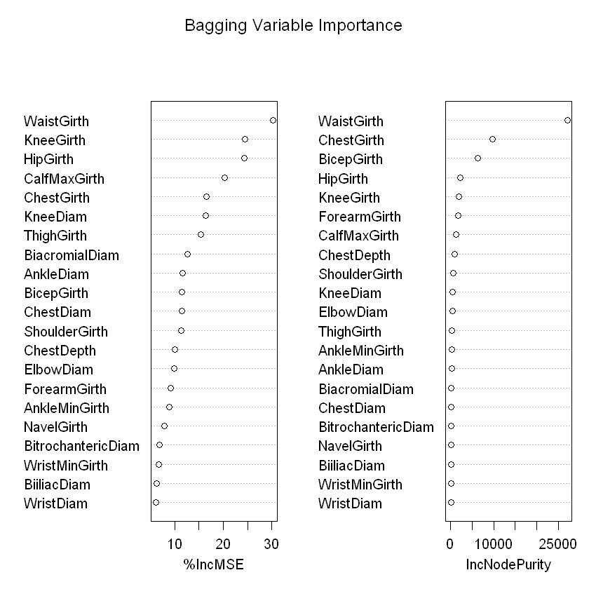

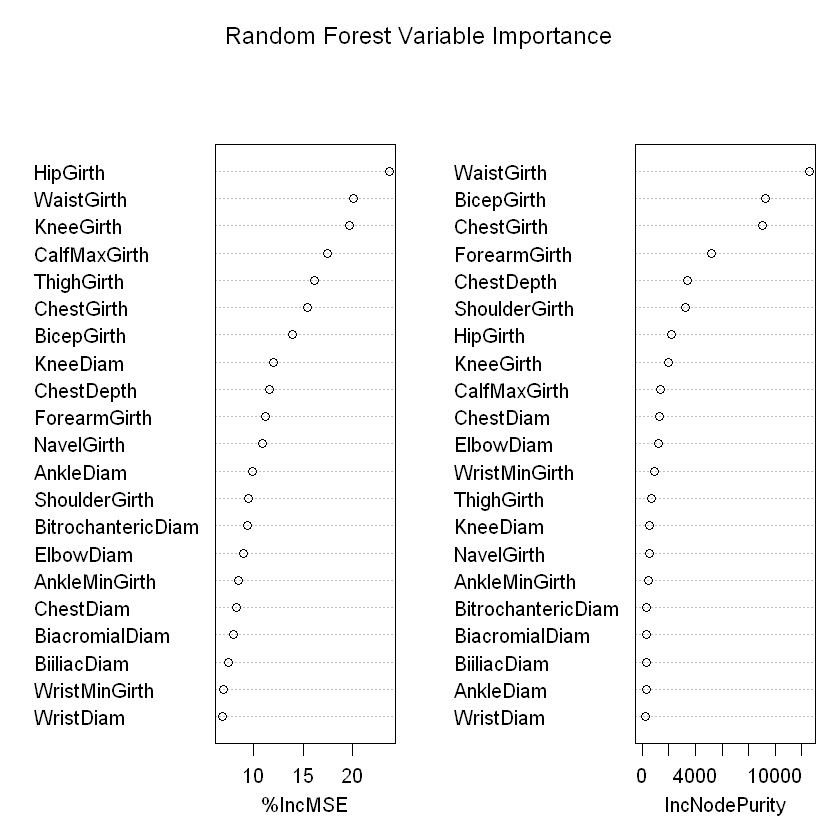

```r
# Bagging importance
importance(bag_model)
varImpPlot(bag_model, main = "Bagging Variable Importance")

# Random Forest importance
importance(rf_model)
varImpPlot(rf_model, main = "Random Forest Variable Importance")
```

## (c)

```r
# Final MSEs using 500 trees
mse_bag_final <- mse(predict(bag_model, newdata = X_test), Y_test)
mse_rf_final <- mse(predict(rf_model, newdata = X_test), Y_test)

# Reusing previous results from PCR/PLSR/Stepwise
data.frame(Method = c("Bagging", "Random Forest", "PCR", "PLSR", "Stepwise"),
           Test_MSE = c(mse_bag_final, mse_rf_final, mse_pcr, mse_plsr, mse_step))
```

A data.frame: 5 × 2

| Method <chr> | Test_MSE <dbl> |
| --- | --- |
| Bagging | 11.686014 |
| Random Forest | 11.160688 |
| PCR | 8.346818 |
| PLSR | 8.946276 |
| Stepwise | 8.465733 |

## (d)

### We examine the MSE vs. number of trees plot. If the MSE curve flattens around 300–400 trees, then 500 is sufficient. If it continues to decline slowly, increasing the number of trees might help slightly.

## 3(a)

```r
library(ISLR2)
library(e1071)
library(caret)

set.seed(4700)

data(OJ)
train_idx <- sample(1:nrow(OJ), 800)
OJ_train <- OJ[train_idx, ]
OJ_test <- OJ[-train_idx, ]
```

## (b)

```r
svm_linear <- svm(Purchase ~ ., data = OJ_train, kernel = "linear", cost = 0.01)
summary(svm_linear)
```

```
Call:
svm(formula = Purchase ~ ., data = OJ_train, kernel = "linear", cost = 0.01)


Parameters:
   SVM-Type:  C-classification
 SVM-Kernel:  linear
       cost:  0.01

Number of Support Vectors:  429

 ( 215 214 )


Number of Classes:  2

Levels:
 CH MM
```

## (c)

```r
train_pred <- predict(svm_linear, OJ_train)
test_pred <- predict(svm_linear, OJ_test)

train_err <- mean(train_pred != OJ_train$Purchase)
test_err <- mean(test_pred != OJ_test$Purchase)

c(Train_Error = train_err, Test_Error = test_err)
```

**Train_Error**

0.15875

**Test_Error**

0.196296296296296

## (d)

```r
set.seed(4700)
tune_out_linear <- tune(svm, Purchase ~ ., data = OJ_train,
                        kernel = "linear", ranges = list(cost = c(0.01, 0.1, 1, 5, 10)))
summary(tune_out_linear)
```

```
Parameter tuning of 'svm':

- sampling method: 10-fold cross validation

- best parameters:
 cost
  0.1

- best performance: 0.15875

- Detailed performance results:
   cost   error dispersion
1  0.01 0.16375 0.04267529
2  0.10 0.15875 0.04168749
3  1.00 0.16000 0.04241004
4  5.00 0.16250 0.04249183
5 10.00 0.16250 0.03952847
```

## (e)

```r
best_linear <- tune_out_linear$best.model

best_train_pred <- predict(best_linear, OJ_train)
best_test_pred <- predict(best_linear, OJ_test)

best_train_err <- mean(best_train_pred != OJ_train$Purchase)
best_test_err <- mean(best_test_pred != OJ_test$Purchase)

c(Train_Error = best_train_err, Test_Error = best_test_err)
```

**Train_Error**

0.15625

**Test_Error**

0.203703703703704

## (f)

```r
set.seed(4700)
tune_out_radial <- tune(svm, Purchase ~ ., data = OJ_train,
                        kernel = "radial", ranges = list(cost = c(0.01, 0.1, 1, 5, 10)))
summary(tune_out_radial)
```

```
Parameter tuning of 'svm':

- sampling method: 10-fold cross validation

- best parameters:
 cost
    1

- best performance: 0.1725

- Detailed performance results:
   cost   error dispersion
1  0.01 0.39500 0.04338138
2  0.10 0.17375 0.04693746
3  1.00 0.17250 0.04887626
4  5.00 0.17875 0.05560588
5 10.00 0.18375 0.04825065
```

```r
best_radial <- tune_out_radial$best.model
radial_test_err <- mean(predict(best_radial, OJ_test) != OJ_test$Purchase)
radial_test_err
```

0.192592592592593

## (g)

```r
set.seed(4700)
tune_out_poly <- tune(svm, Purchase ~ ., data = OJ_train,
                      kernel = "polynomial", degree = 2,
                      ranges = list(cost = c(0.01, 0.1, 1, 5, 10)))
summary(tune_out_poly)
```

```
Parameter tuning of 'svm':

- sampling method: 10-fold cross validation

- best parameters:
 cost
    5

- best performance: 0.1625

- Detailed performance results:
   cost   error dispersion
1  0.01 0.39750 0.04116363
2  0.10 0.31750 0.04456581
3  1.00 0.18625 0.03747684
4  5.00 0.16250 0.04750731
5 10.00 0.16750 0.04609772
```

```r
best_poly <- tune_out_poly$best.model
poly_test_err <- mean(predict(best_poly, OJ_test) != OJ_test$Purchase)
poly_test_err
```

0.203703703703704

## (h)

```r
data.frame(
  Model = c("Linear SVM (cost=0.01)",
            "Linear SVM (tuned)",
            "Radial SVM (tuned)",
            "Polynomial SVM (tuned, deg=2)"),
  Test_Error = c(test_err, best_test_err, radial_test_err, poly_test_err)
)
```

A data.frame: 4 × 2

| Model <chr> | Test_Error <dbl> |
| --- | --- |
| Linear SVM (cost=0.01) | 0.1962963 |
| Linear SVM (tuned) | 0.2037037 |
| Radial SVM (tuned) | 0.1925926 |
| Polynomial SVM (tuned, deg=2) | 0.2037037 |

### Radial SVM performs best due to its flexibility in modeling nonlinear decision boundaries.

## 4

```r
# Loading packages
library(ISLR2)
library(tibble)
library(lubridate)
library(keras)
reticulate::use_condaenv(condaenv = "r-tensorflow")

# Loading NYSE data
data(NYSE)
NYSE <- as_tibble(NYSE)

NYSE$Date <- seq.Date(from = as.Date("2000-01-01"), by = "day", length.out = nrow(NYSE))
NYSE$day_of_week <- wday(NYSE$Date, label = FALSE)  # 1 = Sunday, ..., 7 = Saturday

# Extracting and scaling predictors
xdata <- data.matrix(NYSE[, c("DJ_return", "log_volume", "log_volatility")])
xdata <- scale(xdata)

# Adding scaled day_of_week
dow <- scale(NYSE$day_of_week)
xdata <- cbind(xdata, dow)

# Storing training indicator
istrain <- NYSE$train
```

```r
# Helper function for lagging
lagm <- function(x, k = 1) {
  n <- nrow(x)
  pad <- matrix(NA, k, ncol(x))
  rbind(pad, x[1:(n - k), ])
}

# Generating 5 lags for each row
lags <- lapply(1:5, function(k) lagm(xdata, k))
names(lags) <- paste0("L", 1:5)
arframe <- do.call(cbind, lags)
arframe <- arframe[-(1:5), ]  # Remove first 5 rows

# Scaling response: log_volume, aligning with predictors
y <- scale(NYSE$log_volume)[-(1:5)]

# Matching train indicator
istrain <- istrain[-(1:5)]

# Cleaning NA rows
keep <- complete.cases(arframe)
arframe <- arframe[keep, ]
y <- y[keep]
istrain <- istrain[keep]

# Converting to 3D array
n_timesteps <- 5
n_features <- ncol(xdata)

X <- array(as.numeric(unlist(arframe)),
           dim = c(nrow(arframe), n_timesteps, n_features))

# Splitting into training and test sets
X_train <- X[istrain, , ]
X_test <- X[!istrain, , ]
y_train <- y[istrain]
y_test <- y[!istrain]
```

```r
# Defining model
model <- keras_model_sequential() %>%
  layer_simple_rnn(units = 16, input_shape = c(n_timesteps, n_features)) %>%
  layer_dense(units = 1)

# Compiling model
model %>% compile(
  loss = "mse",
  optimizer = "adam"
)

# Training model
history <- model %>% fit(
  X_train, y_train,
  epochs = 30,
  batch_size = 32,
  validation_split = 0.2
)
```

```r
# Predicting
y_pred <- model %>% predict(X_test)

# Computing R-squared
SSE <- sum((y_test - y_pred)^2)
SST <- sum((y_test - mean(y_test))^2)
R2 <- 1 - SSE / SST
R2
```

0.366868865871896

## 5

```r
# Setting up image directory and loading images
img_dir <- "C:/Users/yello/Pictures/train"  # Replace with your folder path
image_names <- list.files(img_dir, pattern = "\\.png$", full.names = TRUE)
num_images <- length(image_names)
x <- array(dim = c(num_images, 224, 224, 3))

for (i in 1:num_images) {
  img <- image_load(image_names[i], target_size = c(224, 224))
  x[i,,,] <- image_to_array(img)
}

# Preprocessing the images for ResNet50
x <- imagenet_preprocess_input(x)

# Loading pretrained ResNet50 model
model <- application_resnet50(weights = "imagenet")

# Predicting classes for images
predictions <- model %>% predict(x)

# Decoding predictions (
decoded <- imagenet_decode_predictions(predictions, top = 5)

# Results
names(decoded) <- basename(image_names)
print(decoded)
```

```
$IMG_2347.png
  class_name class_description      score
1  n02124075      Egyptian_cat 0.30681780
2  n02123597       Siamese_cat 0.17143214
3  n04493381               tub 0.09994143
4  n04589890     window_screen 0.05671982
5  n02808440           bathtub 0.05540142

$IMG_2348.png
  class_name class_description      score
1  n02123597       Siamese_cat 0.50780451
2  n02124075      Egyptian_cat 0.20013914
3  n02123159         tiger_cat 0.08262066
4  n02123394       Persian_cat 0.06356525
5  n02127052              lynx 0.03628525

$IMG_2349.png
  class_name class_description       score
1  n02489166  proboscis_monkey 0.977820396
2  n02486261             patas 0.011681858
3  n02487347           macaque 0.003738613
4  n02488291            langur 0.001902774
5  n02493509              titi 0.001308246

$IMG_2350.png
  class_name class_description      score
1  n02447366            badger 0.55421680
2  n02398521      hippopotamus 0.09347657
3  n02117135             hyena 0.08438696
4  n02486410            baboon 0.05482996
5  n02480855           gorilla 0.02589290

$IMG_2351.png
  class_name  class_description       score
1  n01616318            vulture 0.919079721
2  n01795545       black_grouse 0.020467123
3  n02017213 European_gallinule 0.019087777
4  n02077923           sea_lion 0.008842708
5  n02018207      American_coot 0.007362524

```

[output cut: 24 more lines]

```
$IMG_2355.png
  class_name            class_description       score
1  n01774750                    tarantula 0.908256590
2  n01773549                  barn_spider 0.045092132
3  n01773797                garden_spider 0.041602042
4  n01775062                  wolf_spider 0.001914562
5  n01773157 black_and_gold_garden_spider 0.001511682

$IMG_2356.png
  class_name         class_description      score
1  n02410509                     bison 0.29081827
2  n02939185                   caldron 0.12808096
3  n02408429             water_buffalo 0.11296942
4  n02093256 Staffordshire_bullterrier 0.07871875
5  n01795545              black_grouse 0.05867470
```